# Regresi Peubah Lag

G1401211094 Hanifa Rahmacindia Nasution

2023-09-17

# Regresi Peubah Lag Sederhana

## Loading Packages

```r
library(dLagM)
library(dynlm)
library(MLmetrics)
library(lmtest)
library(car)
```

## Input Data

```r
data <- rio::import("https://raw.githubusercontent.com/HanifaNasution/Praktikum-MPDW/main/Pertemuan%203/Data%203_Regresi%20Lag%20Sederhana.csv")
str(data)
```

```
## 'data.frame':    731 obs. of  5 variables:
##  $ t          : int  1 2 3 4 5 6 7 8 9 10 ...
##  $ date       : chr  "1/1/2019" "1/2/2019" "1/3/2019" "1/4/2019" ...
##  $ TS (Yt)    : num  12.82 9.33 9.83 9.9 6.77 ...
##  $ TS (Yt-1)  : num  NA 12.82 9.33 9.83 9.9 ...
##  $ T2MDEW (Xt): num  11.26 8.46 9.35 8.9 4.43 ...
```

```r
data
```

```
##       t       date TS (Yt) TS (Yt-1) T2MDEW (Xt)
## 1     1   1/1/2019   12.82        NA       11.26
## 2     2   1/2/2019    9.33     12.82        8.46
## 3     3   1/3/2019    9.83      9.33        9.35
## 4     4   1/4/2019    9.90      9.83        8.90
## 5     5   1/5/2019    6.77      9.90        4.43
## 6     6   1/6/2019    7.49      6.77        5.47
## 7     7   1/7/2019   10.66      7.49        8.42
## 8     8   1/8/2019   13.04     10.66       11.44
## 9     9   1/9/2019    4.65     13.04        1.31
## 10   10  1/10/2019    0.35      4.65       -3.54
## 11   11  1/11/2019    2.92      0.35       -0.20
## 12   12  1/12/2019    7.17      2.92        6.26
## 13   13  1/13/2019    7.44      7.17        5.89
## 14   14  1/14/2019    3.93      7.44        1.87
```

[output cut: 717 more lines]

## Pembagian Data

80% data sebagai data training

20% data sebagai data testing

total data 731 baris

baris 1-585 sebagai data training

baris 586-731 sebagai data testing

```r
#SPLIT DATA
train<-data[1:585,]
test<-data[586:731,]
```

```r
#data time series
train.ts<-ts(train)
test.ts<-ts(test)
data.ts<-ts(data)
```

### Model Koyck

Model Koyck didasarkan pada asumsi bahwa semakin jauh jarak lag peubah independen dari periode sekarang maka semakin kecil pengaruh peubah lag terhadap peubah dependen.

Koyck mengusulkan suatu metode untuk menduga model dinamis distributed lag dengan mengasumsikan bahwa semua koefisien $\beta$ mempunyai tanda sama.

Model kyock merupakan jenis paling umum dari model infinite distributed lag dan juga dikenal sebagai geometric lag

$$y_t=a(1-\lambda)+\beta_0X_t+\beta_1Z_t+\lambda Y_{t-1}+V_t$$

dengan
$$V_t=u_t-\lambda
u_{t-1}$$

#### Pemodelan

Pemodelan model Koyck dengan `R` dapat menggunakan `dLagM::koyckDlm()`

Fungsi `koyckDlm()` akan menerapkan model lag terdistribusi dengan transformasi Koyck satu prediktor. Nilai `x` dan `y` tidak perlu sebagai objek *time series* (`ts`). `intercept` dapat dibuat `TRUE` untuk memasukkan intersep ke dalam model.

```r
# Model Koyck
model.koyck <- koyckDlm(x = train$`T2MDEW (Xt)`, y = train$`TS (Yt)`)
summary(model.koyck)
```

```
##
## Call:
## "Y ~ (Intercept) + Y.1 + X.t"
##
## Residuals:
##      Min       1Q   Median       3Q      Max
## -24.0641  -1.9300   0.9068   3.0092  12.3879
##
## Coefficients:
##             Estimate Std. Error t value Pr(>|t|)
## (Intercept)   1.2353     0.4969   2.486  0.01320 *
## Y.1           1.4269     0.1567   9.109  < 2e-16 ***
## X.t          -0.6541     0.2055  -3.183  0.00154 **
## ---
## Signif. codes:  0 '***' 0.001 '**' 0.01 '*' 0.05 '.' 0.1 ' ' 1
##
## Residual standard error: 5.246 on 581 degrees of freedom
## Multiple R-Squared: 0.6166,  Adjusted R-squared: 0.6153
## Wald test: 666.2 on 2 and 581 DF,  p-value: < 2.2e-16
##
## Diagnostic tests:
## NULL
##
##                              alpha       beta      phi
## Geometric coefficients:  -2.893876 -0.6540932 1.426883
```

```r
AIC(model.koyck)
```

```
## [1] 3598.135
```

```r
BIC(model.koyck)
```

```
## [1] 3615.614
```

Dari hasil tersebut, didapat bahwa peubah $x_t$ dan $y_{t-1}$ memiliki nilai $P-Value<0.05$. Hal ini menunjukkan bahwa peubah $x_t$ dan $y_{t-1}$ berpengaruh signifikan terhadap nilai $y$. Adapun model keseluruhannya adalah sebagai berikut

$$\hat{Y_t}=1.2353-0.6541X_t+1.4269Y_{t-1}$$

#### Peramalan dan Akurasi

Berikut adalah hasil peramalan y untuk 146 periode kedepan menggunakan model koyck (146 karena banyak data test)

```r
fore.koyck <- forecast(model = model.koyck, x=test$`T2MDEW (Xt)`, h=146)
fore.koyck
```

```
## $forecasts
##   [1] 2.897854e+01 3.007154e+01 3.048647e+01 3.091500e+01 3.076118e+01
##   [6] 3.101917e+01 3.063509e+01 3.168305e+01 3.361005e+01 3.688294e+01
##  [11] 4.361991e+01 5.174145e+01 6.106023e+01 7.591379e+01 9.735665e+01
##  [16] 1.269916e+02 1.684530e+02 2.266914e+02 3.098300e+02 4.280340e+02
##  [21] 5.968216e+02 8.375441e+02 1.181106e+03 1.671308e+03 2.370561e+03
##  [26] 3.369503e+03 4.795414e+03 6.829721e+03 9.736627e+03 1.388511e+04
##  [31] 1.980437e+04 2.824836e+04 4.029707e+04 5.748716e+04 8.201497e+04
##  [36] 1.170132e+05 1.669530e+05 2.382104e+05 3.398867e+05 4.849686e+05
##  [41] 6.919827e+05 9.873704e+05 1.408855e+06 2.010266e+06 2.868412e+06
##  [46] 4.092883e+06 5.840059e+06 8.333073e+06 1.189031e+07 1.696608e+07
##  [51] 2.420861e+07 3.454286e+07 4.928863e+07 7.032912e+07 1.003515e+08
##  [56] 1.431898e+08 2.043152e+08 2.915340e+08 4.159850e+08 5.935622e+08
##  [61] 8.469441e+08 1.208491e+09 1.724375e+09 2.460482e+09 3.510822e+09
##  [66] 5.009534e+09 7.148021e+09 1.019939e+10 1.455335e+10 2.076593e+10
```

[output cut: 23 more lines]

```r
mape.koyck <- MAPE(fore.koyck$forecasts, test$`TS (Yt)`)
mape.koyck
```

```
## [1] 5.283079e+19
```

```r
#akurasi data training
GoF(model.koyck)
```

```
##               n    MAE        MPE      MAPE    sMAPE     MASE      MSE     MRAE
## model.koyck 584 3.7563 -0.3284125 0.8405654 0.338301 1.726592 27.37456 5.031572
##                GMRAE
## model.koyck 1.798101
```

### Regression with Distributed Lag

Pemodelan model Regression with Distributed Lag dengan `R` dapat menggunakan `dLagM::dlm()`

Fungsi `dlm()` akan menerapkan model lag terdistribusi dengan satu atau lebih prediktor. Nilai `x` dan `y` tidak perlu sebagai objek *time series* (`ts`). $q$ adalah integer yang mewakili panjang *lag* yang terbatas.

Waktu yang diperlukan bagi variabel X dalam mempengaruhi variabel tak bebas Y disebut beda kala atau lag (Nurahman et al. 2016).

#### Pemodelan contoh (Lag=2)

```r
model.dlm <- dlm(x = train$`T2MDEW (Xt)`,y = train$`TS (Yt)` , q = 2)
summary(model.dlm)
```

```
##
## Call:
## lm(formula = model.formula, data = design)
##
## Residuals:
##     Min      1Q  Median      3Q     Max
## -5.1028 -1.7795 -0.3771  1.0975  8.6957
##
## Coefficients:
##              Estimate Std. Error t value Pr(>|t|)
## (Intercept)  2.361024   0.230651  10.236  < 2e-16 ***
## x.t          0.935912   0.027836  33.622  < 2e-16 ***
## x.1         -0.008154   0.039105  -0.209    0.835
## x.2          0.213075   0.027842   7.653 8.25e-14 ***
## ---
## Signif. codes:  0 '***' 0.001 '**' 0.01 '*' 0.05 '.' 0.1 ' ' 1
##
## Residual standard error: 2.557 on 579 degrees of freedom
## Multiple R-squared:  0.9091, Adjusted R-squared:  0.9086
## F-statistic:  1930 on 3 and 579 DF,  p-value: < 2.2e-16
##
## AIC and BIC values for the model:
##        AIC      BIC
## 1 2754.994 2776.835
```

```r
AIC(model.dlm)
```

```
## [1] 2754.994
```

```r
BIC(model.dlm)
```

```
## [1] 2776.835
```

$$\hat{Y_t}=2.361024+0.935912X_t-0.008154X_{t-1}+0.213075X_{t-2}$$

#### Peramalan dan Akurasi

Berikut merupakan hasil peramalan $y$ untuk 146 periode kedepan (146 karena banyak data test)

```r
fore.dlm <- forecast(model = model.dlm, x=test$`T2MDEW (Xt)`, h=146)
fore.dlm
```

```
## $forecasts
##   [1] 24.0363829 24.2077652 25.7335189 26.0427196 27.5085790 26.8690922
##   [7] 28.2006405 25.7520938 25.3993222 24.1360718 21.0444830 23.0336681
##  [13] 25.5893775 23.8194239 24.2225516 25.0943232 26.1806185 27.8032009
##  [19] 28.0040237 28.9132910 28.7173834 29.0258952 28.8716340 28.9390432
##  [25] 29.2127215 27.5131445 26.8287199 26.8781296 20.7098200 19.9053865
##  [31] 18.7559263 21.5410744 21.3933138 24.9707195 25.5435919 26.3087575
##  [37] 24.4404587 25.8031939 24.9030674 22.8206772 23.9601402 19.5783197
##  [43] 19.1399349 14.7465937 12.9409492 14.9786260 17.0736149 22.3093772
##  [49] 22.6228297 22.1777034 23.1244497 23.1586931 16.3410191 15.4040361
##  [55] 14.1948972 10.1165070 10.5086300 12.7794552 13.2818070 14.7517498
##  [61] 17.1072310 16.0622039 22.0331589 24.4832699 24.6697262 25.2251639
##  [67] 16.9707485 18.4346749 18.3745468 11.2964508  8.7239094 14.6782156
##  [73] 17.2419230 18.9171972 21.6954269 22.2048929 23.1003653 22.5160515
##  [79] 19.4121331 20.7215985 22.5425954 25.7029217 18.8962492 12.4786444
```

[output cut: 17 more lines]

```r
mape.dlm <- MAPE(fore.dlm$forecasts, test$`TS (Yt)`)
mape.dlm
```

```
## [1] 0.1840693
```

```r
#akurasi data training
GoF(model.dlm)
```

```
##             n     MAE        MPE      MAPE     sMAPE      MASE      MSE
## model.dlm 583 1.95314 -0.0055051 0.1981412 0.1596062 0.8965789 6.491652
##               MRAE     GMRAE
## model.dlm 7.187005 0.9989056
```

#### *Lag* Optimum

```r
#penentuan lag optimum
finiteDLMauto(formula = TS..Yt. ~ T2MDEW..Xt.,
              data = data.frame(train), q.min = 1, q.max = 583,
              model.type = "dlm", error.type = "AIC", trace = TRUE)
```

```
##     q - k    MASE        AIC       BIC   GMRAE     MBRAE R.Adj.Sq    Ljung-Box
## 292   292 0.00000       -Inf      -Inf 0.00000   0.00000      NaN          NaN
## 293   293 0.00000       -Inf      -Inf 0.00000   0.00000      NaN          NaN
## 294   294 0.00000       -Inf      -Inf 0.00000   0.00000      NaN          NaN
## 295   295 0.00000       -Inf      -Inf 0.00000   0.00000      NaN          NaN
## 296   296 0.00000       -Inf      -Inf 0.00000   0.00000      NaN          NaN
## 297   297 0.00000       -Inf      -Inf 0.00000   0.00000      NaN          NaN
## 298   298 0.00000       -Inf      -Inf 0.00000   0.00000      NaN          NaN
## 299   299 0.00000       -Inf      -Inf 0.00000   0.00000      NaN          NaN
## 300   300 0.00000       -Inf      -Inf 0.00000   0.00000      NaN          NaN
## 301   301 0.00000       -Inf      -Inf 0.00000   0.00000      NaN          NaN
## 302   302 0.00000       -Inf      -Inf 0.00000   0.00000      NaN          NaN
## 303   303 0.00000       -Inf      -Inf 0.00000   0.00000      NaN          NaN
## 304   304 0.00000       -Inf      -Inf 0.00000   0.00000      NaN          NaN
## 305   305 0.00000       -Inf      -Inf 0.00000   0.00000      NaN          NaN
```

[output cut: 569 more lines]

Banyak data train sebesar 585 data dan q max = banyak data train - 2 (dari error misal q max > banyak data train - 2) sehingga didapat q max = 585 - 2 = 583 Berdasarkan output tersebut, lag optimum didapatkan ketika lag=291. Selanjutnya dilakukan pemodelan untuk lag = 291

```r
#model dlm dengan lag optimum
options(max.print=3000) # agar bisa banyak dan keseluruhan data
model.dlm2 <- dlm(x = train$`T2MDEW (Xt)`,y = train$`TS (Yt)` , q = 291)
summary(model.dlm2)
```

[output not shown]

[output cut: 340 more lines]

```
## x.287       -1.451e-01  8.161e-02  -1.778   0.3261
## x.288        1.964e-01  6.748e-02   2.911   0.2107
## x.289       -1.267e-01  7.239e-02  -1.750   0.3304
## x.290        2.367e-01  1.149e-01   2.060   0.2878
## x.291        1.106e-02  3.107e-02   0.356   0.7824
## ---
## Signif. codes:  0 '***' 0.001 '**' 0.01 '*' 0.05 '.' 0.1 ' ' 1
##
## Residual standard error: 0.326 on 1 degrees of freedom
## Multiple R-squared:      1,  Adjusted R-squared:  0.9983
## F-statistic: 583.3 on 292 and 1 DF,  p-value: 0.033
##
## AIC and BIC values for the model:
##         AIC      BIC
## 1 -907.6749 175.2975
```

```r
AIC(model.dlm2)
```

```
## [1] -907.6749
```

```r
BIC(model.dlm2)
```

```
## [1] 175.2975
```

Dari hasil tersebut terdapat beberapa peubah yang berpengaruh signifikan terhadap taraf nyata 5% yaitu $x_t$. Adapun keseluruhan model yang terbentuk adalah

$$\hat{Y_t}=1.604e^1+9.966e^{-1}X_t+...+1.106e^{-2}X_{t-291}$$

```r
#peramalan dan akurasi
fore.dlm2 <- forecast(model = model.dlm2, x=test$`T2MDEW (Xt)`, h=146)
fore.dlm2
```

```
## $forecasts
##   [1]  -0.2164241   3.3044939  44.9391405  28.1853636  12.8369527  36.2254250
##   [7]  32.3463860  34.4333378  14.5107770  26.6692363  27.4396448  21.9047139
##  [13]  -7.5658817  -1.6192425  18.3941312  40.3409716  40.8098959  22.5359160
##  [19]  19.9913500  12.4467368   4.6359194   0.3158247  14.8330162  51.4914179
##  [25]  36.7321603  24.7651084  35.2293955  20.8738764  26.8428766   5.8726903
##  [31]  14.3034404   9.3424837   0.6195269  20.0121994  35.9850391  54.7273566
##  [37]  34.9942274   4.6659600  11.5461479   5.9085421  12.6728470  21.4253640
##  [43]  31.8475949  38.0991458  30.4072883   1.5512445  11.8714746  23.0009022
##  [49]  28.6744453  30.5615514   7.0651439  15.1585481  19.3390826  26.8791269
##  [55]  37.2243896  30.2937867  30.0064940   1.2628887 -13.7200546  -1.4032801
##  [61]  11.8176449  34.3805419  40.2483518  45.1535664  43.6841485  29.2257109
##  [67]   6.7620421  13.9832345  19.5047617   5.2799046  -1.0083769  12.1734357
##  [73]  24.9808087  29.4851091  31.0867123  24.2981182  14.2103683  32.7381905
##  [79]   3.7790613  30.7142475  35.7238044  12.5064437  25.1339178  15.1234172
```

[output cut: 17 more lines]

```r
mape.dlm2<- MAPE(fore.dlm2$forecasts, test$`TS (Yt)`)
mape.dlm2
```

```
## [1] 0.9224825
```

```r
#akurasi data training
GoF(model.dlm2)
```

```
##              n        MAE         MPE        MAPE       sMAPE        MASE
## model.dlm2 294 0.01491962 0.000453249 0.002330576 0.002368704 0.006108534
##                     MSE       MRAE       GMRAE
## model.dlm2 0.0003615151 0.02926192 0.006759869
```

Model tersebut merupakan model yang sangat tidak baik karena MAPE data test sebesar 0,92. Sedangkan MAPE data train sebesar 0.0023 atau bisa diindikasikan terjadi overfitting. Sementara dilakukan pemotongan panjang lag untuk menanggulangi hal tersebut.

```r
#penentuan lag optimum menangani overfitting
finiteDLMauto(formula = TS..Yt. ~ T2MDEW..Xt.,
              data = data.frame(train), q.min = 1, q.max = 33,
              model.type = "dlm", error.type = "AIC", trace = TRUE)
```

```
##    q - k    MASE      AIC      BIC   GMRAE     MBRAE R.Adj.Sq Ljung-Box
## 33    33 0.67887 2346.933 2502.221 0.74517   0.35291  0.94135         0
## 32    32 0.68068 2353.292 2504.329 0.71735  -0.14428  0.94104         0
## 31    31 0.68467 2359.920 2506.703 0.73984   0.35312  0.94084         0
## 30    30 0.68767 2370.892 2513.418 0.74204   0.20902  0.94035         0
## 29    29 0.69240 2380.834 2519.099 0.74856   0.39725  0.94015         0
## 28    28 0.69268 2385.457 2519.457 0.73987   0.47511  0.94041         0
## 27    27 0.69107 2389.482 2519.213 0.73965   0.42269  0.94041         0
## 26    26 0.68971 2395.117 2520.575 0.72167   0.53101  0.94033         0
## 25    25 0.68848 2398.137 2519.319 0.72786   0.46829  0.94065         0
## 24    24 0.69632 2405.762 2522.665 0.74028   0.49392  0.94056         0
## 23    23 0.70069 2415.189 2527.808 0.73596   0.37988  0.94021         0
## 22    22 0.70268 2426.938 2535.270 0.73306  -0.15261  0.93928         0
## 21    21 0.70606 2436.089 2540.130 0.76020  -1.73595  0.93881         0
## 20    20 0.70578 2441.469 2541.216 0.75351   0.82305  0.93904         0
```

[output cut: 19 more lines]

Didapat optimum lag sebesar 33

```r
#model dlm dengan lag optimum
model.dlm2_potonglag <- dlm(x = train$`T2MDEW (Xt)`,y = train$`TS (Yt)` , q = 33)
summary(model.dlm2_potonglag)
```

```
##
## Call:
## lm(formula = model.formula, data = design)
##
## Residuals:
##     Min      1Q  Median      3Q     Max
## -5.0643 -1.2375 -0.1286  1.0024  6.9648
##
## Coefficients:
##               Estimate Std. Error t value Pr(>|t|)
## (Intercept)  6.358e-01  2.140e-01   2.971  0.00311 **
## x.t          7.537e-01  2.539e-02  29.684  < 2e-16 ***
## x.1          3.357e-02  3.516e-02   0.955  0.34021
## x.2          2.020e-02  3.669e-02   0.550  0.58228
## x.3          1.832e-02  3.677e-02   0.498  0.61848
## x.4          6.757e-03  3.676e-02   0.184  0.85423
## x.5          1.067e-02  3.673e-02   0.290  0.77160
## x.6          1.875e-02  3.666e-02   0.511  0.60925
## x.7          1.584e-02  3.655e-02   0.433  0.66499
## x.8          1.206e-02  3.666e-02   0.329  0.74228
## x.9          3.715e-02  3.675e-02   1.011  0.31245
## x.10        -6.079e-03  3.650e-02  -0.167  0.86780
## x.11         1.658e-02  3.620e-02   0.458  0.64713
## x.12         2.013e-02  3.635e-02   0.554  0.57986
## x.13         1.269e-02  3.641e-02   0.348  0.72763
## x.14        -6.421e-04  3.599e-02  -0.018  0.98577
## x.15         2.101e-02  3.529e-02   0.595  0.55191
## x.16         1.919e-02  3.516e-02   0.546  0.58540
## x.17         8.283e-03  3.514e-02   0.236  0.81373
## x.18         6.912e-03  3.518e-02   0.196  0.84433
## x.19         1.444e-02  3.540e-02   0.408  0.68355
## x.20         2.847e-02  3.547e-02   0.803  0.42253
## x.21        -1.638e-03  3.543e-02  -0.046  0.96315
## x.22         1.265e-02  3.531e-02   0.358  0.72022
## x.23         2.623e-02  3.530e-02   0.743  0.45774
## x.24         1.498e-02  3.530e-02   0.424  0.67144
## x.25         3.618e-02  3.519e-02   1.028  0.30435
## x.26        -1.007e-02  3.497e-02  -0.288  0.77341
## x.27         1.564e-02  3.501e-02   0.447  0.65530
## x.28         1.344e-02  3.504e-02   0.384  0.70150
## x.29        -9.703e-05  3.507e-02  -0.003  0.99779
## x.30         1.724e-02  3.503e-02   0.492  0.62286
## x.31         4.402e-02  3.496e-02   1.259  0.20856
## x.32         4.953e-03  3.347e-02   0.148  0.88244
## x.33         4.942e-02  2.426e-02   2.037  0.04215 *
## ---
## Signif. codes:  0 '***' 0.001 '**' 0.01 '*' 0.05 '.' 0.1 ' ' 1
##
## Residual standard error: 1.963 on 517 degrees of freedom
## Multiple R-squared:  0.945,  Adjusted R-squared:  0.9414
## F-statistic: 261.1 on 34 and 517 DF,  p-value: < 2.2e-16
##
## AIC and BIC values for the model:
##        AIC      BIC
## 1 2346.933 2502.221
```

```r
AIC(model.dlm2_potonglag)
```

```
## [1] 2346.933
```

```r
BIC(model.dlm2_potonglag)
```

```
## [1] 2502.221
```

Dari hasil tersebut terdapat beberapa peubah yang berpengaruh signifikan terhadap taraf nyata 5% yaitu $x_t$ , $x_{t-33}$. Adapun keseluruhan model yang terbentuk adalah

$$\hat{Y_t}=6.358e^{-1}+7.537e^{-1}X_t+...+4.942e^{-2}X_{t-33}$$

Adapun hasil peramalan 146 periode kedepan menggunakan model tersebut adalah sebagai berikut (146 sebanyak data test)

```r
#peramalan dan akurasi
fore.dlm2_potonglag <- forecast(model = model.dlm2_potonglag, x=test$`T2MDEW (Xt)`, h=146)
fore.dlm2_potonglag
```

```
## $forecasts
##   [1] 26.084044 26.442485 27.705639 27.759624 28.774634 28.183450 29.027856
##   [8] 27.214948 26.552833 25.951587 23.608177 25.128290 27.773959 26.183420
##  [15] 25.750940 26.905083 27.654657 28.726028 28.778862 29.160627 29.147229
##  [22] 29.495989 29.333296 29.470787 29.749250 28.302038 27.533611 27.898223
##  [29] 23.090334 22.173855 22.101660 24.548072 24.387880 26.657039 27.246594
##  [36] 27.463538 26.002799 26.911015 26.402649 24.658224 25.464970 22.116749
##  [43] 21.655462 18.629389 17.046584 19.152570 21.203983 24.892851 24.748123
##  [50] 23.734524 24.350755 24.549592 18.752299 17.533159 17.821290 14.538345
##  [57] 14.567007 16.928034 17.131265 17.310399 19.087717 17.505072 22.119254
##  [64] 24.467480 23.735752 23.945629 17.598695 18.337149 19.589040 13.683518
##  [71] 11.177208 17.101932 19.448822 19.561773 21.007945 21.100119 21.497269
##  [78] 20.959546 18.619806 19.871783 22.359730 24.680196 18.896208 12.993633
##  [85] 14.821831 13.578258  5.988980  7.699383 11.035569 13.764836 16.753688
##  [92] 19.232889 20.128406 20.679604 21.902346 22.821906 18.104251 14.435026
##  [99] 14.900609 14.458615  8.634617  7.840389  6.832857  7.700521 13.185596
## [106] 14.354489 14.837498  8.666973 10.174946 16.464353 12.808062 13.300526
## [113] 13.029598 13.324062  5.929773  1.725606  1.566265  5.475477  8.929258
## [120]  6.213797  7.913453  4.743932  4.553082  7.503346  9.271853 11.736318
## [127] 14.282896 10.176978  6.941742  6.311298  6.503341  1.296035  1.314459
## [134]  4.104507  8.121023  7.500753  5.634170  8.025816  3.834839 -4.356817
## [141] -1.703250  3.022073  7.578949  7.510629 10.290391 12.235599
##
## $call
## forecast.dlm(model = model.dlm2_potonglag, x = test$`T2MDEW (Xt)`,
##     h = 146)
##
## attr(,"class")
## [1] "forecast.dlm" "dLagM"
```

```r
mape.dlm2_potonglag<- MAPE(fore.dlm2_potonglag$forecasts, test$`TS (Yt)`)
mape.dlm2_potonglag
```

```
## [1] 0.1784692
```

```r
#akurasi data training
GoF(model.dlm2_potonglag)
```

```
##                        n      MAE         MPE      MAPE     sMAPE      MASE
## model.dlm2_potonglag 552 1.428532 -0.03543161 0.1283875 0.1065991 0.6788688
##                          MSE     MRAE     GMRAE
## model.dlm2_potonglag 3.60881 5.486253 0.7451675
```

Model tersebut merupakan model yang baik dengan nilai MAPE yang 17%. Sedangkan MAPE data train sebesar 12% yang mana nilai MAPE antara keduanya tidak berbeda jauh sehingga diindikasikan tidak terjadi overfitting maupun underfitting.

### Model Autoregressive

Peubah dependen dipengaruhi oleh peubah independen pada waktu sekarang, serta dipengaruhi juga oleh peubah dependen itu sendiri pada satu waktu yang lalu maka model tersebut disebut *autoregressive* (Gujarati 2004).

#### Pemodelan

Pemodelan Autoregressive dilakukan menggunakan fungsi `dLagM::ardlDlm()` . Fungsi tersebut akan menerapkan *autoregressive* berordo $(p,q)$ dengan satu prediktor.

Dengan $p$ adalah integer yang mewakili panjang *lag* yang terbatas dan $q$ adalah integer yang merepresentasikan ordo dari proses *autoregressive*.

p = panjang lag x (peubah dependen dipengaruhi beberapa waktu yang lalu dari peubah indipenden) contoh p = 3 berarti xtminus nya sampai xt-3 q = ordo autoregressive (peubah dependen dipengaruhi beberapa waktu yang lalu dari peubah dependen itu sendiri) contoh q = 1 berarti ytminus nya sampai yt-1

```r
model.ardl <- ardlDlm(x = train$`T2MDEW (Xt)`, y = train$`TS (Yt)`, p = 1 , q = 1)
summary(model.ardl)
```

```
##
## Time series regression with "ts" data:
## Start = 2, End = 585
##
## Call:
## dynlm(formula = as.formula(model.text), data = data, start = 1)
##
## Residuals:
##     Min      1Q  Median      3Q     Max
## -5.2923 -0.7025  0.0991  0.8037  3.0925
##
## Coefficients:
##             Estimate Std. Error t value Pr(>|t|)
## (Intercept)  0.32851    0.12158   2.702   0.0071 **
## X.t          0.71848    0.01399  51.366   <2e-16 ***
## X.1         -0.59208    0.02199 -26.921   <2e-16 ***
## Y.1          0.88614    0.01939  45.704   <2e-16 ***
## ---
## Signif. codes:  0 '***' 0.001 '**' 0.01 '*' 0.05 '.' 0.1 ' ' 1
##
## Residual standard error: 1.251 on 580 degrees of freedom
## Multiple R-squared:  0.9782, Adjusted R-squared:  0.9781
## F-statistic:  8683 on 3 and 580 DF,  p-value: < 2.2e-16
```

```r
AIC(model.ardl)
```

```
## [1] 1925.212
```

```r
BIC(model.ardl)
```

```
## [1] 1947.062
```

Hasil di atas menunjukkan bahwa semua hasil uji t menunjukkan nilai-p pada peubah $<0.05$. Hal ini menunjukkan bahwa peubah $x_t$, $x_{t-1}$, dan $y_{t-1}$ berpengaruh signifikan terhadap $y_t$.Model keseluruhannya adalah sebagai berikut:

$$\hat{Y}=0.32851+0.71848X_t-0.59208X_{t-1}+0.88614Y_{t-1}$$

#### Peramalan dan Akurasi

```r
fore.ardl <- forecast(model = model.ardl, x=test$`T2MDEW (Xt)`, h=146)
fore.ardl
```

```
## $forecasts
##   [1] 27.22118569 27.11704569 28.03342794 27.98894720 28.64213186 28.00371818
##   [7] 28.69646568 26.87635046 26.23395452 25.48069029 23.01645863 24.34191595
##  [13] 26.65963720 24.94895621 24.56918428 25.51380992 26.38580587 27.42555124
##  [19] 27.46896786 28.00997865 27.96802614 28.17267271 28.16122626 28.24368762
##  [25] 28.52891152 27.28455957 26.67032381 26.94203251 22.31217166 21.26593691
##  [31] 21.10081367 23.13055437 22.89928006 25.02101752 25.56020901 25.72161074
##  [37] 24.24885281 25.22981573 24.93375039 23.11162736 23.94080328 20.96727786
##  [43] 20.17914604 17.24574356 15.59958853 17.36457885 19.05886289 22.52148645
##  [49] 22.50564397 21.47821591 22.26950596 22.64359153 17.32935747 16.23921657
##  [55] 16.25458927 13.08687184 12.90980157 14.99528163 15.21315450 15.69214826
##  [61] 17.36855545 16.50751568 20.68393469 23.06561563 22.63323032 22.83670422
##  [67] 16.91292133 17.82266377 19.09989229 13.43792964 10.75709803 16.14701495
##  [73] 18.66021859 18.76382564 20.42531684 21.02826941 21.56277015 21.21927495
##  [79] 18.89456391 19.97184393 21.98329604 24.33478711 18.95824871 13.37874280
```

[output cut: 18 more lines]

Data di atas merupakan hasil peramalan untuk 146 periode ke depan menggunakan Model Autoregressive dengan $p=1$ dan $q=1$.

```r
mape.ardl <- MAPE(fore.ardl$forecasts, test$`TS (Yt)`)
mape.ardl
```

```
## [1] 0.2311872
```

```r
#akurasi data training
GoF(model.ardl)
```

```
##              n       MAE         MPE      MAPE      sMAPE      MASE      MSE
## model.ardl 584 0.9617628 -0.02321533 0.1165914 0.09642897 0.4420765 1.555187
##                MRAE     GMRAE
## model.ardl 2.166806 0.4954044
```

#### *Lag* Optimum

```r
#penentuan lag optimum
model.ardl.opt <- ardlBoundOrders(data = data.frame(train), ic = "AIC",
                                  formula = TS..Yt. ~ T2MDEW..Xt. )
min_p=c()

### ERROR ###
### for(i in 1:585){
#  min_p[i]=min(model.ardl.opt$Stat.table[[i]])
#}
#q_opt=which(min_p==min(min_p, na.rm = TRUE))
#p_opt=which(model.ardl.opt$Stat.table[[q_opt]] ==
#              min(model.ardl.opt$Stat.table[[q_opt]], na.rm = TRUE))
#data.frame("q_optimum" = q_opt, "p_optimum" = p_opt,
#           "AIC"=model.ardl.opt$min.Stat)
```

```r
pqop<-ardlBoundOrders(data = data.frame(train) , ic = "AIC", formula = TS..Yt. ~ T2MDEW..Xt. )
c(p=pqop$p, q=pqop$q)
```

```
## $p.T2MDEW..Xt.
## [1] 3
##
## $q
## [1] 15
```

Dari tabel di atas, dapat terlihat bahwa nilai AIC terendah didapat ketika $p=3$ dan $q=15$, Artinya, model autoregressive optimum didapat ketika $p=3$ dan $q=15$.

Selanjutnya dapat dilakukan pemodelan dengan nilai $p$ dan $q$ optimum seperti inisialisasi di langkah sebelumnya.

```r
model.ardl_optimum <- ardlDlm(x = train$`T2MDEW (Xt)`, y = train$`TS (Yt)`, p = 3 , q = 15)
summary(model.ardl_optimum)
```

```
##
## Time series regression with "ts" data:
## Start = 16, End = 585
##
## Call:
## dynlm(formula = as.formula(model.text), data = data, start = 1)
##
## Residuals:
##     Min      1Q  Median      3Q     Max
## -5.1056 -0.6558  0.1001  0.8089  2.6816
##
## Coefficients:
##              Estimate Std. Error t value Pr(>|t|)
## (Intercept)  0.116686   0.125372   0.931   0.3524
## X.t          0.698259   0.014966  46.656   <2e-16 ***
## X.1         -0.434442   0.034340 -12.651   <2e-16 ***
## X.2         -0.045868   0.039150  -1.172   0.2419
## X.3         -0.046556   0.033391  -1.394   0.1638
## Y.1          0.671397   0.043042  15.599   <2e-16 ***
## Y.2          0.041264   0.051879   0.795   0.4267
## Y.3          0.032940   0.046818   0.704   0.4820
## Y.4          0.063102   0.028651   2.202   0.0280 *
## Y.5         -0.034113   0.028631  -1.191   0.2340
## Y.6          0.029861   0.028500   1.048   0.2952
## Y.7          0.003124   0.028353   0.110   0.9123
## Y.8          0.006565   0.028208   0.233   0.8161
## Y.9          0.019689   0.028336   0.695   0.4875
## Y.10        -0.025224   0.028444  -0.887   0.3756
## Y.11         0.025077   0.028498   0.880   0.3793
## Y.12        -0.003361   0.028472  -0.118   0.9061
## Y.13         0.017704   0.028315   0.625   0.5321
## Y.14        -0.029074   0.026934  -1.079   0.2809
## Y.15         0.047445   0.018781   2.526   0.0118 *
## ---
## Signif. codes:  0 '***' 0.001 '**' 0.01 '*' 0.05 '.' 0.1 ' ' 1
##
## Residual standard error: 1.206 on 550 degrees of freedom
## Multiple R-squared:   0.98,  Adjusted R-squared:  0.9793
## F-statistic:  1416 on 19 and 550 DF,  p-value: < 2.2e-16
```

```r
AIC(model.ardl_optimum)
```

```
## [1] 1852.811
```

```r
BIC(model.ardl_optimum)
```

```
## [1] 1944.07
```

Hasil di atas menunjukkan bahwa hasil uji t peubah $x_t$, $x_{t-1}$, $y_{t-1}$, $y_{t-4}$, dan $y_{t-15}$ menunjukkan nilai-p pada peubah $<0.05$. Hal ini menunjukkan bahwa peubah $x_t$, $x_{t-1}$, $y_{t-1}$, $y_{t-4}$, dan $y_{t-15}$ berpengaruh signifikan terhadap $y_t$.Model keseluruhannya adalah sebagai berikut:

$$\hat{Y}=0.116686+0.698259X_t-0.434442X_{t-1}+...+0.671397Y_{t-1}+...+0.047445Y_{t-15}$$

```r
# Peramalan 146 periode (sebanyak data test)
fore.ardl_optimum <- forecast(model = model.ardl_optimum, x=test$`T2MDEW (Xt)`, h=146)
fore.ardl_optimum
```

```
## $forecasts
##   [1] 26.9988488 27.0036159 28.0382939 28.2201522 28.9037447 28.2741181
##   [7] 29.0581771 27.3239758 26.8147297 26.0659735 23.9935700 25.3745477
##  [13] 27.8863433 26.3591022 25.9036941 26.8968850 27.8092022 28.7943136
##  [19] 28.7640467 29.2563046 29.1408932 29.3569532 29.1892123 29.2750771
##  [25] 29.5580193 28.2716208 27.5926908 28.0091917 23.6723718 22.7002911
##  [31] 22.8175972 25.2172523 25.0760982 27.2317089 27.6520959 27.7924035
##  [37] 26.1365124 27.0182647 26.7389241 25.0175928 25.7600846 22.8496708
##  [43] 22.2873839 19.3462889 18.0033882 19.6990899 21.7908975 25.0539128
##  [49] 24.9093481 23.7268573 24.2170907 24.5461736 19.1844831 18.1425036
##  [55] 18.2800917 15.5963796 15.3256093 17.5436923 17.8729020 18.0864517
##  [61] 19.5504910 18.5187668 22.5541731 24.7337346 24.0393583 23.6993391
##  [67] 17.9540367 18.5987880 19.8115642 14.6353381 11.7607178 17.3279170
##  [73] 20.1269297 20.0588114 21.2888090 21.8441707 22.1648151 21.5929196
##  [79] 19.3057766 20.3489137 22.6392281 24.7361022 19.1306708 13.7260049
```

[output cut: 18 more lines]

```r
mape.ardl_optimum <- MAPE(fore.ardl_optimum$forecasts, test$`TS (Yt)`)
mape.ardl_optimum
```

```
## [1] 0.2723092
```

```r
#akurasi data training
GoF(model.ardl_optimum)
```

```
##                      n       MAE         MPE      MAPE      sMAPE      MASE
## model.ardl_optimum 570 0.9087237 -0.02840011 0.1083042 0.08681478 0.4191911
##                         MSE     MRAE     GMRAE
## model.ardl_optimum 1.403522 2.171365 0.4689122
```

Didapat nilai MAPE data test sebesar 27% yang mana masih kurang baik serta MAPE data train sebesar 10%. Diindikasikan terjadi overfitting pada model tersebut.

### Perbandingan Model

```r
akurasi <- matrix(c(mape.koyck, mape.dlm, mape.dlm2, mape.dlm2_potonglag, mape.ardl, mape.ardl_optimum))
row.names(akurasi)<- c("Koyck","DLM 1","DLM 2 (Optimum)","DLM 2 (Optimum) Penanganan Overfitting","Autoregressive", "Autoregressive Lag Optimum")
colnames(akurasi) <- c("MAPE")
akurasi
```

```
##                                                MAPE
## Koyck                                  5.283079e+19
## DLM 1                                  1.840693e-01
## DLM 2 (Optimum)                        9.224825e-01
## DLM 2 (Optimum) Penanganan Overfitting 1.784692e-01
## Autoregressive                         2.311872e-01
## Autoregressive Lag Optimum             2.723092e-01
```

Berdasarkan nilai MAPE, model paling optimum didapat pada Model DLM Lag Optimum Pasca Penanganan Overfitting dengan memotong panjang lag karena memiliki nilai MAPE yang terkecil.

### Plot

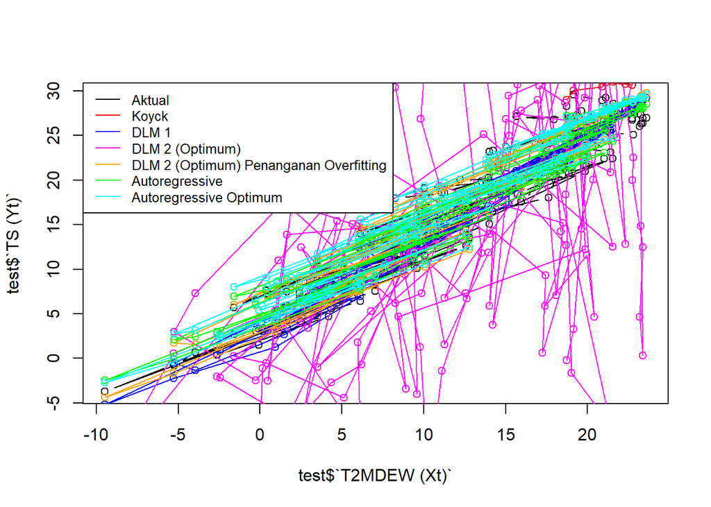

```r
par(mfrow=c(1,1))
plot(test$`T2MDEW (Xt)`, test$`TS (Yt)`, type="b", col="black")

#Garis Koyck
points(test$`T2MDEW (Xt)`, fore.koyck$forecasts,col="red")
lines(test$`T2MDEW (Xt)`, fore.koyck$forecasts,col="red")

#Garis DLM 1
points(test$`T2MDEW (Xt)`, fore.dlm$forecasts,col="blue")
lines(test$`T2MDEW (Xt)`, fore.dlm$forecasts,col="blue")

#Garis DLM 2 (Optimum)
points(test$`T2MDEW (Xt)`, fore.dlm2$forecasts,col="magenta")
lines(test$`T2MDEW (Xt)`, fore.dlm2$forecasts,col="magenta")

#Garis DLM 2 (Optimum) Penanganan Overfitting
points(test$`T2MDEW (Xt)`, fore.dlm2_potonglag$forecasts,col="orange")
lines(test$`T2MDEW (Xt)`, fore.dlm2_potonglag$forecasts,col="orange")

# Garis Autoregressive
points(test$`T2MDEW (Xt)`, fore.ardl$forecasts,col="green")
lines(test$`T2MDEW (Xt)`, fore.ardl$forecasts,col="green")

# Garis Autoregressive Optimum
points(test$`T2MDEW (Xt)`, fore.ardl_optimum$forecasts,col="cyan")
lines(test$`T2MDEW (Xt)`, fore.ardl_optimum$forecasts,col="cyan")

legend("topleft",c("Aktual", "Koyck","DLM 1","DLM 2 (Optimum)", "DLM 2 (Optimum) Penanganan Overfitting","Autoregressive", "Autoregressive Optimum"), lty=1, col=c("black","red","blue","magenta","orange","green","cyan"), cex=0.8)
```

Berdasarkan plot tersebut, terlihat bahwa plot yang paling mendekati data aktualnya adalah Model DLM Lag Optimum Pasca Penanganan Overfitting dengan memotong panjang lag, sehingga dapat disimpulkan model terbaik dalam hal ini adalah model regresi DLM